# 审查元素(F12)与HTML: 简介

[figure not shown]

## 按下 F12

害怕: 这是什么?

惊喜: 所有的网页上的文字都在这里

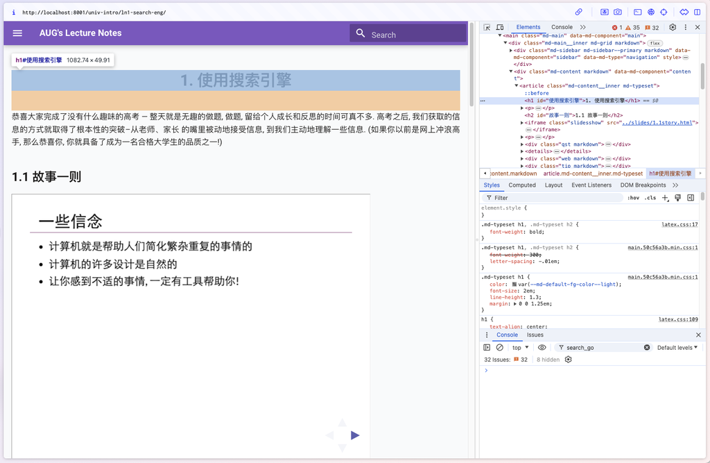

## HTML标签

- 像是大括号一样
  - 左括号(开启): `<xxx>` (xxx是这个标签的名字)
  - 右括号(关闭): `</xxx>` (xxx是这个标签的名字)
- 缩写: `<xxx/>`

中间: xxx的具体信息

- `<xxx width=200px> contents </xxx>`: 宽度为200px的xxx

可以的xxx

- h1: heading of 1(一级标题)
- div: 一个”容器”
- input: 输入框
- …

## 实战: 修改页面

- HTML只负责呈现画面
- 刷新一下就复原了

## 烦人的情况(1)

- 不登录不让复制

[figure not shown]

## 烦人的情况(2)

- 鼠标移出视频视频自动暂停

# JS: 做交互

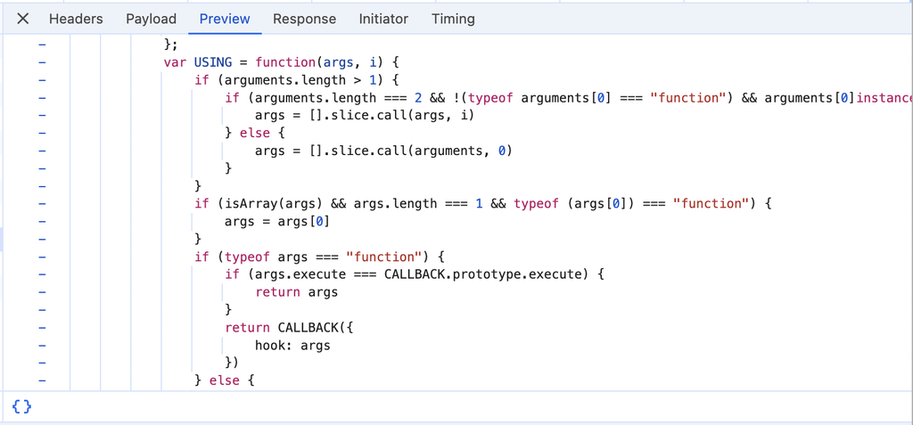

## 事件

Knock, knock, who’s there?

- 有人敲门, 我去**开门.**
  - 敲门: 事件; 开门: 事件的响应(一段JS代码)
- 事件: 点击; 鼠标移动到窗口外; …
- 网页版本的连点器
  - 只要一直”响应”就好啦!
- 移出鼠标不再暂停的视频
  - 干脆别响应这个事件了!
    - 移出鼠标
    - 解绑函数

## 控制台(Console)

- JS的游乐场
- 对/错/结果立刻显示

常见操作

- 获取网页上的元素到JS
- 点击它
- 隔一段时间就点一下它

## 能不能自动化?

- 每次都要自动输入
- 扩展
  - 油猴脚本

> 让你感到不舒服的事情, 总是有办法做的!